# 🌍 CLIMATE CHANGE MODELING

# Calculate the number of characters or words in each comment, and categorize them into 'big' or 'small' groups depending on length.

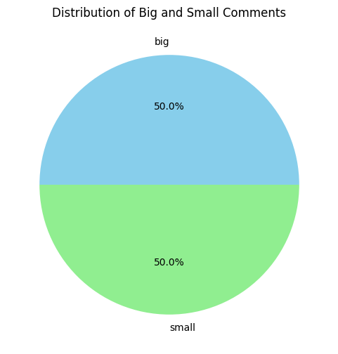

```python
# Calculate the length of each text comment
df['text_length'] = df['text'].astype(str).apply(len)

# Define thresholds for 'big' and 'small'
threshold = df['text_length'].median()  # Median as the threshold
df['size'] = df['text_length'].apply(lambda x: 'big' if x > threshold else 'small')


size_counts = df['size'].value_counts()
plt.figure(figsize=(6, 6))
plt.pie(size_counts, labels=size_counts.index, autopct='%1.1f%%', colors=['skyblue', 'lightgreen'])
plt.title('Distribution of Big and Small Comments')
plt.show()
```

# Detect null entries

```python
print("\nNull Value Summary:")
print(df.isnull().sum())
```

```
Null Value Summary:
date               0
likesCount         0
profileName        0
commentsCount    278
text              18
text_length        0
size               0
dtype: int64
```

```python
print("\nDataset Statistics:")
print(df.describe())
```

```
Dataset Statistics:
       likesCount  commentsCount  text_length
count  522.000000     244.000000   522.000000
mean     4.720307       8.696721   179.141762
std     12.053556      12.266176   519.944862
min      0.000000       1.000000     1.000000
25%      0.000000       2.000000    37.000000
50%      1.000000       5.000000    88.500000
75%      4.000000      10.000000   176.000000
max    126.000000      93.000000  7649.000000
```

# Generate statistical plots

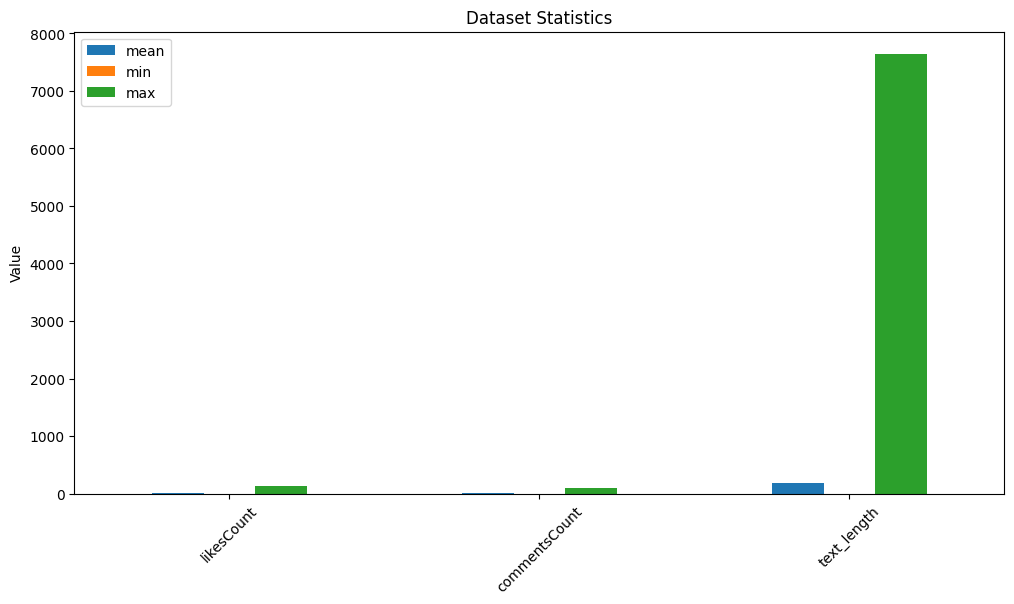

```python
stats = df.describe().transpose()


stats_to_plot = stats[['mean', 'min', 'max']]


stats_to_plot.plot(kind='bar', figsize=(12, 6))
plt.title('Dataset Statistics')
plt.ylabel('Value')
plt.xticks(rotation=45)
plt.show()
```

# Column-wise mean statistics

```python
stats_to_plot = stats['mean'].reset_index()
stats_to_plot.columns = ['Feature', 'Mean']

fig = px.bar(stats_to_plot, x='Feature', y='Mean', title='Mean Statistics per Feature')
fig.show()
```

[interactive chart not shown]

# Perform Exploratory Data Analysis (EDA)

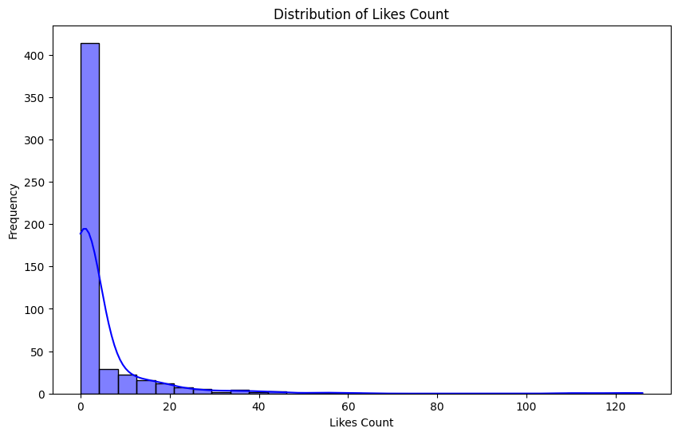

```python
plt.figure(figsize=(10, 6))
sns.histplot(df['likesCount'], bins=30, kde=True, color='blue')
plt.title("Distribution of Likes Count")
plt.xlabel("Likes Count")
plt.ylabel("Frequency")
plt.show()
```

```python
print(df.columns)
```

```
Index(['date', 'likesCount', 'profileName', 'commentsCount', 'text',
       'text_length', 'size'],
      dtype='object')
```

```python
pip install wordcloud
```

```
Downloading wordcloud-1.9.4-cp313-cp313-win_amd64.whl (300 kB)
```

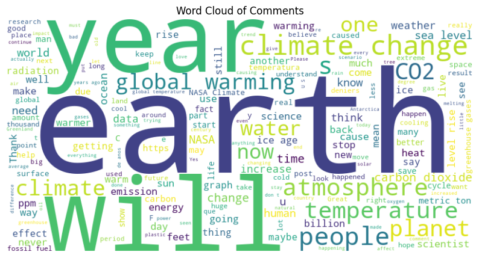

```python
from wordcloud import WordCloud
import matplotlib.pyplot as plt

all_text = " ".join(str(comment) for comment in df['text'].dropna())

# I am gonna Generate  the word cloud

wordcloud = WordCloud(width=800, height=400, background_color='white').generate(all_text)

plt.figure(figsize=(10, 6))
plt.imshow(wordcloud, interpolation='bilinear')
plt.axis('off')
plt.title("Word Cloud of Comments")
plt.show()
```

# Sentiment Labeling

## Why Sentiment Labeling?

- **Track Emotional Trends:** Understand how opinions and emotions change over time.
- **Support Smarter Decisions:** Provides insights for businesses, creators, or researchers to gauge audience feedback.
- **Organize Information:** Makes large datasets easier to sort, filter, and analyze by assigning clear sentiment tags.

```
object
```

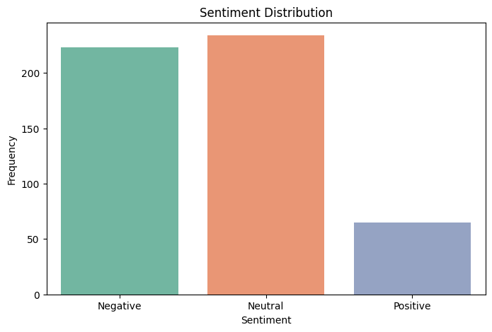

```python
def label_sentiment(likes):
    if likes > 10:
        return "Positive"
    elif likes > 0:
        return "Neutral"
    else:
        return "Negative"

df['Sentiment'] = df['likesCount'].apply(label_sentiment)

print(df['Sentiment'].dtype)

df['Sentiment'] = df['Sentiment'].astype('category')

plt.figure(figsize=(8, 5))
sns.countplot(x=df['Sentiment'], palette='Set2')  # Specify x= for countplot
plt.title("Sentiment Distribution")
plt.xlabel("Sentiment")
plt.ylabel("Frequency")
plt.show()
```